# Comparison of Effects of Fast and High Accuracy Models of Guppy Basecalling Software on Single Nucleotide Polymorphism Calling

Hamza Umut Karakurt, Hasan Ali Pekcan, Ayşe Kahraman, Bilçağ Akgün

2022-08-22

FAST5 files were downloaded from [Nanopore WGS Consortium](https://github.com/nanopore-wgs-consortium/NA12878) using Amazon Web Services (AWS) S3 client.

The command that used:

```bash
guppy_basecaller --compress_fastq -i "input_folder" --cpu_threads_per_caller 14
--num_callers 1 -c dna_r9.4.1_450bps_hac.cfg
```

Obtained FASTQ files (from pass folder) merged using *cat* command in Ubuntu 20.04 OS. Quality of each FASTQ file analyzed via [FastQC](https://www.bioinformatics.babraham.ac.uk/projects/fastqc/) and [MultiQC](https://multiqc.info/) tools.

Fastq files aligned to human genome (hg19) using minimap2 aligner using default parameters.

The command that used:

```bash
minimap2 --MD -a  "genome_loc" "fastq_loc"
```

Output SAM files directly converted to BAM files using [Samtools](https://academic.oup.com/bioinformatics/article/25/16/2078/204688). BAM files indexed using Samtools as well.

SNPs and Indels are called using Clair3 Docker container with default parameters.

VCF files are processed using R/RStudio and compared with [HG001](https://ftp-trace.ncbi.nlm.nih.gov/giab/ftp/release/NA12878_HG001/NISTv4.2.1/GRCh37/) truth vcf file.

Required packages are imported

```r
library(ggplot2)
library(reshape2)
library(ggsci)
library(knitr)
library(stringr)
library(data.table)
library(gridExtra)
```

# Comparison of Number of Fail and Pass FASTQ Files After Basecalling

```r
fail_pass_results <- read.table("fail_pass/fail_pass_ratio.txt" , sep = "\t" , header = T)
fail_pass_results$total <- fail_pass_results$Pass+fail_pass_results$Fail
```

```r
kable(fail_pass_results[,1:5] ,
      caption = "Pass/Fail Ratios of High Accuracy and Fast Models" , align=rep('c', 5))
```

Pass/Fail Ratios of High Accuracy and Fast Models

| Dataset | Model.Type | Pass | Fail | Pass.Fail.Ratio |
| --- | --- | --- | --- | --- |
| FAB39075 | High_Accuracy | 7014 | 5555 | 1.2626463 |
| FAB39075 | Fast | 6878 | 5779 | 1.1901713 |
| FAB42395 | High_Accuracy | 35 | 31 | 1.1290323 |
| FAB42395 | Fast | 37 | 33 | 1.1212121 |
| FAB42260 | High_Accuracy | 49 | 66 | 0.7424242 |
| FAB42260 | Fast | 44 | 70 | 0.6285714 |
| FAB41174 | High_Accuracy | 187 | 125 | 1.4960000 |
| FAB41174 | Fast | 181 | 136 | 1.3308824 |
| FAB42476 | High_Accuracy | 4232 | 2849 | 1.4854335 |
| FAB42476 | Fast | 4022 | 3173 | 1.2675701 |
| FAB42706 | High_Accuracy | 2634 | 2415 | 1.0906832 |
| FAB42706 | Fast | 2498 | 2542 | 0.9826908 |
| FAB43577 | High_Accuracy | 449 | 407 | 1.1031941 |
| FAB43577 | Fast | 435 | 418 | 1.0406699 |
| FAB46644 | High_Accuracy | 3591 | 3066 | 1.1712329 |
| FAB46644 | Fast | 3450 | 3206 | 1.0761073 |
| FAB39088 | Fast | 109 | 87 | 1.2528736 |
| FAB39088 | High_Accuracy | 117 | 80 | 1.4625000 |
| FAB39043 | Fast | 381 | 224 | 1.7008929 |
| FAB39043 | High_Accuracy | 386 | 211 | 1.8293839 |
| FAB42316 | Fast | 56 | 47 | 1.1914894 |
| FAB42316 | High_Accuracy | 58 | 44 | 1.3181818 |
| FAB42473 | Fast | 105 | 120 | 0.8750000 |
| FAB42473 | High_Accuracy | 118 | 109 | 1.0825688 |
| FAB42810 | Fast | 36 | 53 | 0.6792453 |
| FAB42810 | High_Accuracy | 45 | 47 | 0.9574468 |
| FAB44989 | Fast | 12 | 15 | 0.8000000 |
| FAB44989 | High_Accuracy | 13 | 14 | 0.9285714 |
| FAB45332 | Fast | 119 | 103 | 1.1553398 |
| FAB45332 | High_Accuracy | 100 | 122 | 0.8196721 |

The difference is tested using **Paired T-Test**.

First, the differences tested with **Shapiro Wilk Test** to test normality.

```r
shapiro.test(log2(fail_pass_results$total[fail_pass_results$Model.Type == "Fast"]) - log2(fail_pass_results$total[fail_pass_results$Model.Type == "High_Accuracy"]))
```

```
##
##  Shapiro-Wilk normality test
##
## data:  log2(fail_pass_results$total[fail_pass_results$Model.Type == "Fast"]) - log2(fail_pass_results$total[fail_pass_results$Model.Type == "High_Accuracy"])
## W = 0.85798, p-value = 0.02257
```

```r
pass_fail_test <- t.test(log2(fail_pass_results$total[fail_pass_results$Model.Type == "Fast"]) , log2(fail_pass_results$total[fail_pass_results$Model.Type == "High_Accuracy"]) , paired = TRUE)
print(paste("Obtained P-Value is: " , pass_fail_test$p.value))
```

```
## [1] "Obtained P-Value is:  0.445158210877028"
```

The number of generated FASTQ files are not significantly different (p-value = 0.44)

# Comparison of Pass and Fail Ratio

The Pass/Fail ratios are calculated for each model that used for each data set. Ratios are plotted using **ggplot2** and **ggsci** packages.

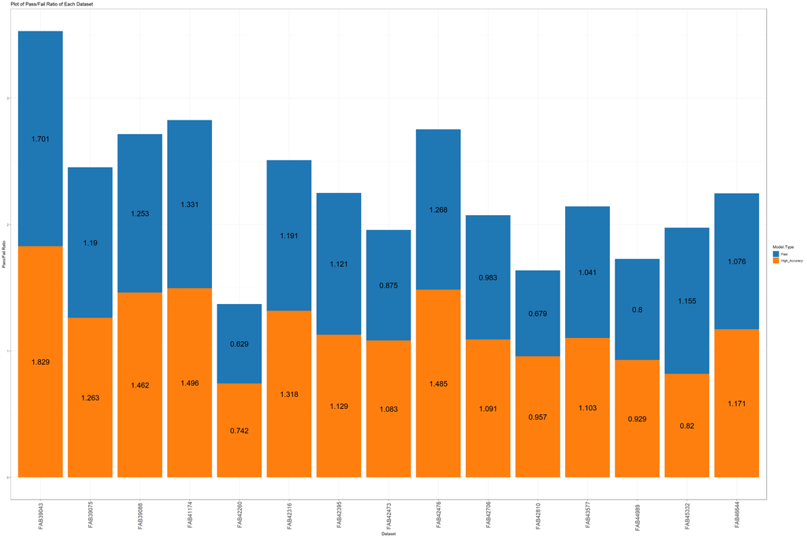

```r
ggplot(fail_pass_results, aes(fill=Model.Type, y=Pass.Fail.Ratio, x=Dataset, label = round(Pass.Fail.Ratio , digits = 3))) + geom_bar(stat = "identity") +
  theme_bw() + geom_text(size = 7, position = position_stack(vjust = 0.5)) + scale_fill_d3() + theme(axis.text.x = element_text(angle = 90, size = 15, vjust = 0.5, hjust=1)) + ggtitle("Plot of Pass/Fail Ratio of Each Dataset") + xlab("Dataset") + ylab("Pass/Fail Ratio")
```

Boxplot of Pass/Fail Ratio

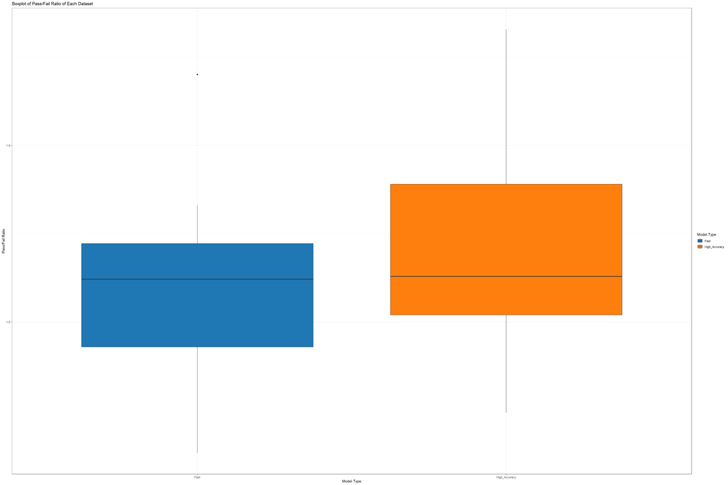

```r
ggplot(fail_pass_results, aes(x = Model.Type , y = Pass.Fail.Ratio , fill = Model.Type)) + geom_boxplot(outlier.color = "black" , outlier.shape = 16) + scale_fill_d3()+ ggtitle("Boxplot of Pass/Fail Ratio of Each Dataset") + xlab("Model Type") + ylab("Pass/Fail Ratio") + theme_bw()
```

Fold Changes of Pass/Fail Ratio

```r
pass_fail_ratio_fcs <- fail_pass_results$Pass.Fail.Ratio[fail_pass_results$Model.Type == "Fast"] / fail_pass_results$Pass.Fail.Ratio[fail_pass_results$Model.Type == "High_Accuracy"]

print(paste("Mean FoldChange of Pass/Fail Ratio is: " , round(mean(pass_fail_ratio_fcs) , digits = 3)))
```

```
## [1] "Mean FoldChange of Pass/Fail Ratio is:  0.918"
```

Average Fold Change pf Pass/Fail Ratios is 0.918.

Pass/Fail Ratios between High Accuracy and Fast models are also tested using Paired T-Test as well.

First, the differences are with **Shapiro Wilk Test** to test normality.

```r
shapiro.test(fail_pass_results$Pass.Fail.Ratio[fail_pass_results$Model.Type == "Fast"] - fail_pass_results$Pass.Fail.Ratio[fail_pass_results$Model.Type == "High_Accuracy"])
```

```
##
##  Shapiro-Wilk normality test
##
## data:  fail_pass_results$Pass.Fail.Ratio[fail_pass_results$Model.Type == "Fast"] - fail_pass_results$Pass.Fail.Ratio[fail_pass_results$Model.Type == "High_Accuracy"]
## W = 0.76504, p-value = 0.001354
```

```r
pass_fail_ratio_test <- t.test(fail_pass_results$Pass.Fail.Ratio[fail_pass_results$Model.Type == "Fast"] , fail_pass_results$Pass.Fail.Ratio[fail_pass_results$Model.Type == "High_Accuracy"] , paired = TRUE)
print(paste("Obtained P-Value is: " , pass_fail_ratio_test$p.value))
```

```
## [1] "Obtained P-Value is:  0.0112650876146224"
```

The P/F Ratios between models are significantly different with p-value = 0.011

# Read Counts in FASTQ Files in Each Model

```r
read_counts <- read.table("fail_pass/read_counts.txt" , header = T , sep = "\t")
```

Boxplot of High Accuracy and Fast model read counts in FASTQ files

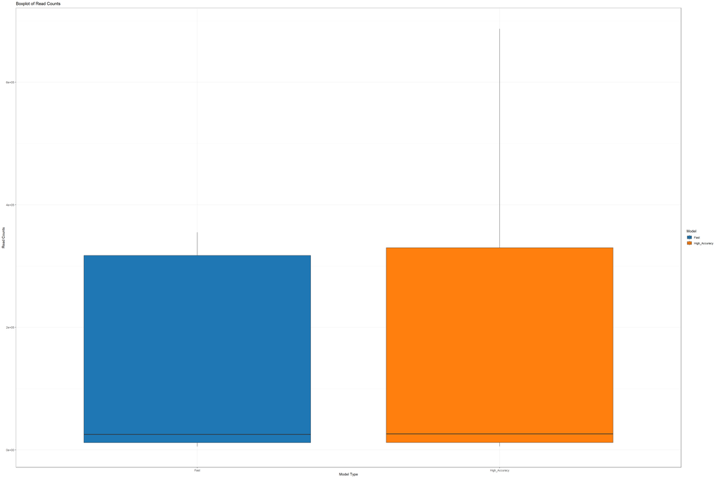

```r
ggplot(read_counts, aes(x = Model , y = Read_Counts , fill = Model)) + geom_boxplot(outlier.color = "black" , outlier.shape = 16) + scale_fill_d3()+ ggtitle("Boxplot of Read Counts") + xlab("Model Type") + ylab("Read Counts") + theme_bw()
```

The total read counts differences are tested using Paired T-Test.

```r
read_counts_test <- t.test(log2(read_counts$Read_Counts[read_counts$Model == "Fast"]) , log2(read_counts$Read_Counts[read_counts$Model == "High_Accuracy"]) , paired = TRUE)
print(paste("Obtained P-Value is: " , read_counts_test$p.value))
```

```
## [1] "Obtained P-Value is:  0.132438662297722"
```

Read counts are not statistically different between models.

# Comparison of Average Read Lengths Between FASTQ Outputs of High Accuracy and Fast Models

```r
read_lengths <- read.table("fail_pass/read_lengths.txt" , header = T , sep = "\t")
```

Boxplot of High Accuracy and Fast Model Average Read Lengths in FASTQ files

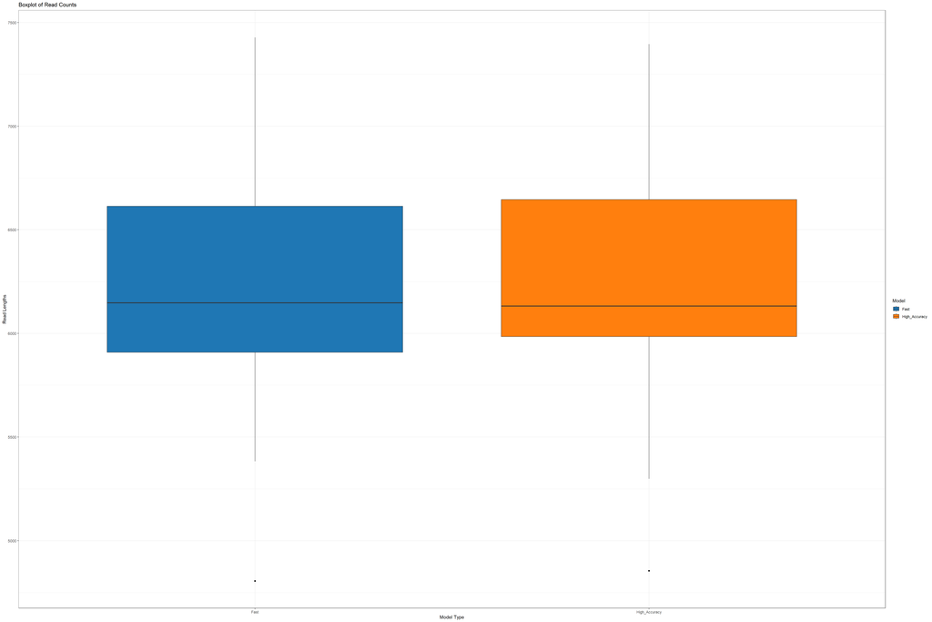

```r
ggplot(read_lengths, aes(x = Model , y = Average_Read_Length , fill = Model)) + geom_boxplot(outlier.color = "black" , outlier.shape = 16) + scale_fill_d3()+ theme_bw() + ggtitle("Boxplot of Read Counts") + xlab("Model Type") + ylab("Read Lengths")
```

The total read counts differences are tested using Paired T-Test.

```r
read_lengths_test <- t.test(log2(read_lengths$Average_Read_Length[read_lengths$Model == "Fast"]) , log2(read_lengths$Average_Read_Length[read_lengths$Model == "High_Accuracy"]) , paired = TRUE)
print(paste("Obtained P-Value is: " , read_lengths_test$p.value))
```

```
## [1] "Obtained P-Value is:  0.680160771056529"
```

The average read lengths between Fast and High Accuracy Models are not statistically different with p-value = 0.68.

# Comparison of Variants

VCF files obtained from Clair3 processed using a in-house R function. HG001 truth VCF file is used to compare true and false variants.

Truth VCF file is imported to R and an ID created for each variant using **Chromosome, Position, Reference Base and Alternative Base**.

```r
truth_file <- read.table("HG001_with_chr.vcf" , sep = "\t")
truth_ids <- paste(truth_file$V1,truth_file$V2,truth_file$V4,truth_file$V5,sep = "_")
```

The folders that contains the SNPs and Indels for each model and data set obtained from Clair3 imported to R. IDs for each variant are created as well.

```r
fast_vcfs_snps <- list.files("clair3_vars/snps/fast" , full.names = T)
hac_vcfs_snps <- list.files("clair3_vars/snps/hac" , full.names = T)

fast_vcfs_indels <- list.files("clair3_vars/indels/fast" , full.names = T)
hac_vcfs_indels <- list.files("clair3_vars/indels/hac" , full.names = T)
```

The in-house function **vcf_comparison** takes a vcf file as input, extract variants with “PASS” and filters variants with quality lower than 12.

```r
vcf_comparison <- function(fast_input , hac_input , dataname) {
  fast_vcf <- read.table(fast_input , sep = "\t" , header = F)
  fast_vcf <- fast_vcf[fast_vcf$V7 == "PASS",]
  fast_vcf <- fast_vcf[as.numeric(fast_vcf$V6) > 12,]
  hac_vcf <- read.table(hac_input , sep = "\t" , header = F)
  hac_vcf <- hac_vcf[hac_vcf$V7 == "PASS",]
  hac_vcf <- hac_vcf[as.numeric(hac_vcf$V6) > 12,]
  fast_vcf$ID <- paste(fast_vcf$V1,fast_vcf$V2,fast_vcf$V4,fast_vcf$V5,sep = "_")
  hac_vcf$ID <- paste(hac_vcf$V1,hac_vcf$V2,hac_vcf$V4,hac_vcf$V5,sep = "_")
  fast_tp <- fast_vcf$ID %in% truth_ids
  hac_tp <- hac_vcf$ID %in% truth_ids
  fast_tp_rate <- sum(fast_tp) / length(fast_tp) * 100
  hac_tp_rate <- sum(hac_tp) / length(hac_tp) * 100
  tp_rates <- c(sum(fast_tp) / length(fast_tp) * 100 , sum(hac_tp) / length(hac_tp) * 100)
  number_of_variants <- c(nrow(fast_vcf) , nrow(hac_vcf))
  number_of_true_variants <- c(sum(fast_tp) , sum(hac_tp))
  number_of_false_variants <- number_of_variants - number_of_true_variants
  comparison_results <- data.frame(Number_of_Variants = number_of_variants,
                                   Number_of_TP_Variants = number_of_true_variants,
                                   Number_of_FP_Variants = number_of_false_variants,
                                   TP_Ratios = tp_rates)
  rownames(comparison_results) <- c(paste(dataname,"_fast" , sep = "") , paste(dataname,"_hac" , sep = ""))
  comparison_results
}
```

```r
sample_names <- list()

for (i in 1:length(fast_vcfs_snps)) {
  sample_names[i] <- substr(str_split(fast_vcfs_snps[i] , pattern = "/")[[1]][4],1,8)
}
```

Each VCF is used as input to function and results are stored in seperate files.

```r
for (i in 1:length(fast_vcfs_snps)) {
  assign(paste(sample_names[i],"_comparison_snps",sep = "") ,
       vcf_comparison(fast_vcfs_snps[i],hac_vcfs_snps[i],sample_names[i]))
}
```

```r
for (i in 1:length(fast_vcfs_indels)) {
  assign(paste(sample_names[i],"_comparison_indels",sep = "") ,
       vcf_comparison(fast_vcfs_indels[i],hac_vcfs_indels[i],sample_names[i]))
}
```

```r
comparisons_snps <- as.data.frame(rbindlist(mget(ls(pattern = "_comparison_snps"))))

comparisons_indels <- as.data.frame(rbindlist(mget(ls(pattern = "_comparison_indels"))))
```

```r
comparisons_snps$Dataset <- as.character(rep(sample_names , each = 2))
comparisons_snps$Model <- as.factor(rep(c("Fast" , "High_Accuracy") , 15))

comparisons_indels$Dataset <- as.character(rep(sample_names , each = 2))
comparisons_indels$Model <- as.factor(rep(c("Fast" , "High_Accuracy") , 15))

snp_results <- comparisons_snps[,c(5,6,1,2,3,4)]
indel_results <- comparisons_indels[,c(5,6,1,2,3,4)]
```

```r
kable(snp_results , caption = "Variant Calling Results (SNPs)")
```

Variant Calling Results (SNPs)

| Dataset | Model | Number_of_Variants | Number_of_TP_Variants | Number_of_FP_Variants | TP_Ratios |
| --- | --- | --- | --- | --- | --- |
| FAB39043 | Fast | 254 | 226 | 28 | 88.97638 |
| FAB39043 | High_Accuracy | 533 | 470 | 63 | 88.18011 |
| FAB39075 | Fast | 35192 | 31144 | 4048 | 88.49739 |
| FAB39075 | High_Accuracy | 67430 | 60538 | 6892 | 89.77903 |
| FAB39088 | Fast | 6 | 6 | 0 | 100.00000 |
| FAB39088 | High_Accuracy | 21 | 20 | 1 | 95.23810 |
| FAB41174 | Fast | 4989 | 4210 | 779 | 84.38565 |
| FAB41174 | High_Accuracy | 9813 | 8360 | 1453 | 85.19311 |
| FAB42260 | Fast | 6 | 3 | 3 | 50.00000 |
| FAB42260 | High_Accuracy | 18 | 12 | 6 | 66.66667 |
| FAB42316 | Fast | 19 | 17 | 2 | 89.47368 |
| FAB42316 | High_Accuracy | 34 | 34 | 0 | 100.00000 |
| FAB42395 | Fast | 234 | 205 | 29 | 87.60684 |
| FAB42395 | High_Accuracy | 536 | 466 | 70 | 86.94030 |
| FAB42473 | Fast | 54 | 43 | 11 | 79.62963 |
| FAB42473 | High_Accuracy | 116 | 103 | 13 | 88.79310 |
| FAB42476 | Fast | 35568 | 30017 | 5551 | 84.39327 |
| FAB42476 | High_Accuracy | 71996 | 62081 | 9915 | 86.22840 |
| FAB42706 | Fast | 28010 | 23616 | 4394 | 84.31275 |
| FAB42706 | High_Accuracy | 59103 | 50908 | 8195 | 86.13438 |
| FAB42810 | Fast | 68 | 62 | 6 | 91.17647 |
| FAB42810 | High_Accuracy | 119 | 100 | 19 | 84.03361 |
| FAB43577 | Fast | 39673 | 33783 | 5890 | 85.15363 |
| FAB43577 | High_Accuracy | 76573 | 65821 | 10752 | 85.95850 |
| FAB44989 | Fast | 84 | 75 | 9 | 89.28571 |
| FAB44989 | High_Accuracy | 144 | 122 | 22 | 84.72222 |
| FAB45332 | Fast | 41 | 33 | 8 | 80.48780 |
| FAB45332 | High_Accuracy | 100 | 89 | 11 | 89.00000 |
| FAB46664 | Fast | 21621 | 17779 | 3842 | 82.23024 |
| FAB46664 | High_Accuracy | 44794 | 37614 | 7180 | 83.97107 |

```r
kable(indel_results , caption = "Variant Calling Results (Indels)")
```

Variant Calling Results (Indels)

| Dataset | Model | Number_of_Variants | Number_of_TP_Variants | Number_of_FP_Variants | TP_Ratios |
| --- | --- | --- | --- | --- | --- |
| FAB39043 | Fast | 0 | 0 | 0 | NaN |
| FAB39043 | High_Accuracy | 0 | 0 | 0 | NaN |
| FAB39075 | Fast | 269 | 187 | 82 | 69.51673 |
| FAB39075 | High_Accuracy | 493 | 408 | 85 | 82.75862 |
| FAB39088 | Fast | 0 | 0 | 0 | NaN |
| FAB39088 | High_Accuracy | 0 | 0 | 0 | NaN |
| FAB41174 | Fast | 17 | 13 | 4 | 76.47059 |
| FAB41174 | High_Accuracy | 60 | 46 | 14 | 76.66667 |
| FAB42260 | Fast | 0 | 0 | 0 | NaN |
| FAB42260 | High_Accuracy | 0 | 0 | 0 | NaN |
| FAB42316 | Fast | 0 | 0 | 0 | NaN |
| FAB42316 | High_Accuracy | 0 | 0 | 0 | NaN |
| FAB42395 | Fast | 0 | 0 | 0 | NaN |
| FAB42395 | High_Accuracy | 1 | 1 | 0 | 100.00000 |
| FAB42473 | Fast | 0 | 0 | 0 | NaN |
| FAB42473 | High_Accuracy | 0 | 0 | 0 | NaN |
| FAB42476 | Fast | 204 | 154 | 50 | 75.49020 |
| FAB42476 | High_Accuracy | 489 | 402 | 87 | 82.20859 |
| FAB42706 | Fast | 133 | 111 | 22 | 83.45865 |
| FAB42706 | High_Accuracy | 361 | 297 | 64 | 82.27147 |
| FAB42810 | Fast | 0 | 0 | 0 | NaN |
| FAB42810 | High_Accuracy | 0 | 0 | 0 | NaN |
| FAB43577 | Fast | 248 | 160 | 88 | 64.51613 |
| FAB43577 | High_Accuracy | 566 | 406 | 160 | 71.73145 |
| FAB44989 | Fast | 0 | 0 | 0 | NaN |
| FAB44989 | High_Accuracy | 0 | 0 | 0 | NaN |
| FAB45332 | Fast | 0 | 0 | 0 | NaN |
| FAB45332 | High_Accuracy | 0 | 0 | 0 | NaN |
| FAB46664 | Fast | 96 | 69 | 27 | 71.87500 |
| FAB46664 | High_Accuracy | 220 | 180 | 40 | 81.81818 |

```r
filtered_snps <- as.data.frame(snp_results)
filtered_snps$Number_of_Variants <- as.integer(filtered_snps$Number_of_Variants)
filtered_indels <- as.data.frame(indel_results[-c(1,2,5,6,9,10,11,12,13,14,15,16,21,22,25,26,27,28),])
```

## Comparison of Single Nucleotide Polymorphmisms (SNPs)

The Barplot of Number of Total SNPs for Each Data Set and Model

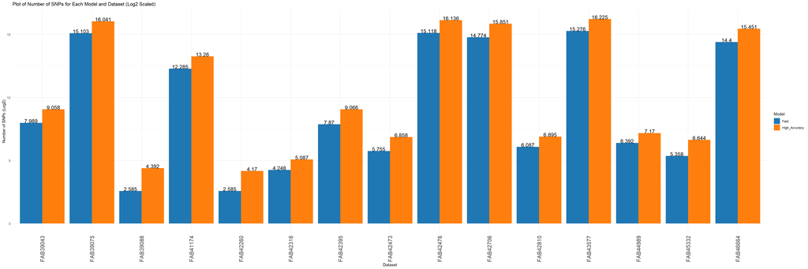

```r
ggplot(filtered_snps , aes(x = Dataset , y = log2(Number_of_Variants) , fill = Model , label = Number_of_Variants)) + geom_bar(stat = 'identity' , position = position_dodge()) + theme_minimal() + scale_fill_d3() + geom_text(aes(label = round(log2(Number_of_Variants),digits = 3)) , size = 5 , vjust = 0 , position = position_dodge(width = 0.9)) + theme(axis.text.x = element_text(angle = 90, size = 15, vjust = 0.5, hjust=1)) + ggtitle("Plot of Number of SNPs for Each Model and Dataset (Log2 Scaled)") + xlab("Dataset") + ylab("Number of SNPs (Log2)")
```

Boxplot of Number of Variants

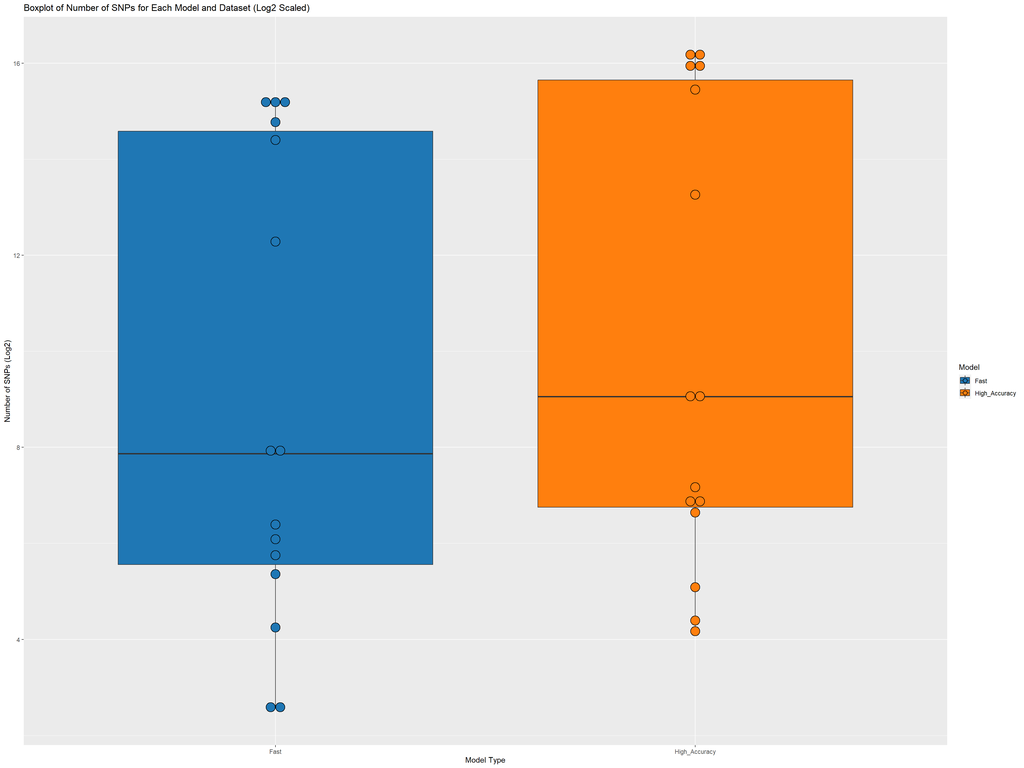

```r
ggplot(filtered_snps , aes(x = Model , y = log2(Number_of_Variants) , fill = Model)) + geom_boxplot(outlier.color = "black" , outlier.shape = 16) + scale_fill_d3() + geom_dotplot(binaxis='y', stackdir='center',position=position_dodge(1) , binwidth = 0.2) + ggtitle("Boxplot of Number of SNPs for Each Model and Dataset (Log2 Scaled)") + xlab("Model Type") + ylab("Number of SNPs (Log2)")
```

### Statistical Testing on Number of Variants

Fold Change Based Analysis

```r
number_of_snps_fcs <- filtered_snps$Number_of_Variants[filtered_snps$Model == "Fast"] / filtered_snps$Number_of_Variants[filtered_snps$Model == "High_Accuracy"]

tp_ratios_snps_fcs <- filtered_snps$TP_Ratios[filtered_snps$Model == "Fast"] / filtered_snps$TP_Ratios[filtered_snps$Model == "High_Accuracy"]

print(paste("Mean FoldChange of Number of SNPs is: " , round(mean(number_of_snps_fcs) , digits = 3)))
```

```
## [1] "Mean FoldChange of Number of SNPs is:  0.475"
```

```r
print(paste("Mean FoldChange of True Positive SNP Ratios is: " , round(mean(tp_ratios_snps_fcs) , digits = 3)))
```

```
## [1] "Mean FoldChange of True Positive SNP Ratios is:  0.97"
```

Average Fold Change of SNPs between Fast and High Accuracy Models in the context of *Number of Variants* is 0.475 while in the context of *True Positive Ratios* is 0.97.

There is a remarkable difference between High Accuracy and Fast models in the context of **Number of Variants**.

The difference is also tested using Paired T - Test to define the significance of differences.

First, the differences are with **Shapiro Wilk Test** to test normality.

```r
shapiro.test(log2(filtered_snps$Number_of_Variants[filtered_snps$Model == "Fast"]) - log2(filtered_snps$Number_of_Variants[filtered_snps$Model == "High_Accuracy"]))
```

```
##
##  Shapiro-Wilk normality test
##
## data:  log2(filtered_snps$Number_of_Variants[filtered_snps$Model == "Fast"]) - log2(filtered_snps$Number_of_Variants[filtered_snps$Model == "High_Accuracy"])
## W = 0.86252, p-value = 0.02624
```

The differences distribute normally (p-value threshold 0.01) with p-value = 0.026

```r
number_of_variants_test_wilcox <- t.test(log2(filtered_snps$Number_of_Variants[filtered_snps$Model == "Fast"]) , log2(filtered_snps$Number_of_Variants[filtered_snps$Model == "High_Accuracy"]) ,paired = TRUE)

print(paste("Obtained P-Value is: " , round(number_of_variants_test_wilcox$p.value,digits = 3)))
```

```
## [1] "Obtained P-Value is:  0"
```

The Number of Variants are significantly different with p-value = 0.

### Statistical Testing on True Positive Ratios

Barplot of True Positive Ratios

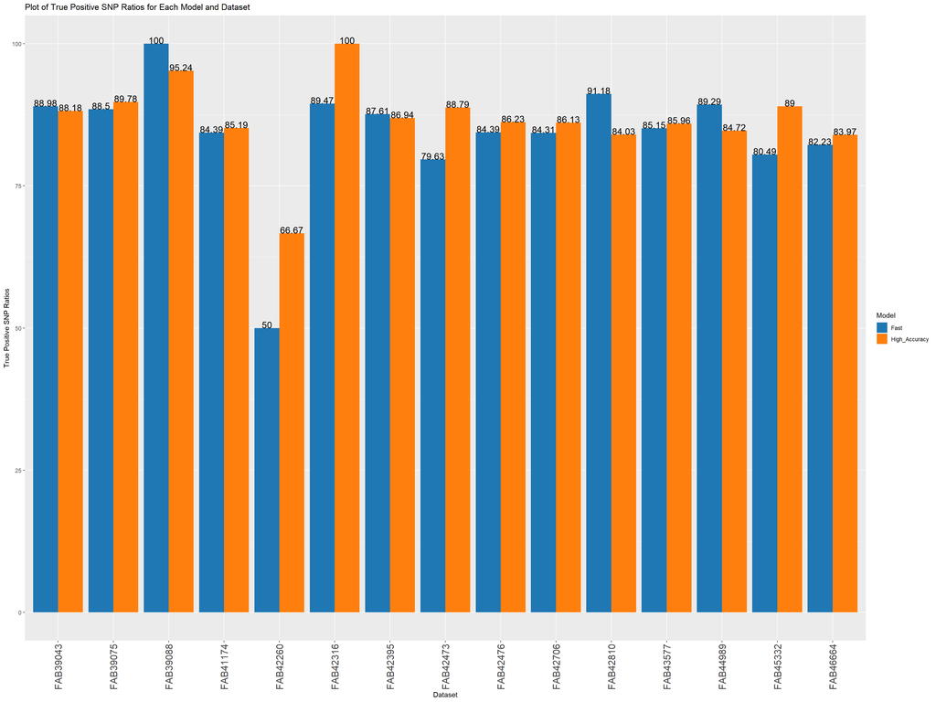

```r
ggplot(filtered_snps , aes(x = Dataset , y=TP_Ratios , fill = Model , label = round(TP_Ratios , digits = 2))) + geom_bar(stat = 'identity' , position = position_dodge())+ scale_fill_d3() + geom_text(aes(label = round(TP_Ratios , digits = 2)) , size = 5 , vjust = 0 , position = position_dodge(width = 0.9)) + theme(axis.text.x = element_text(angle = 90, size = 15, vjust = 0.5, hjust=1)) + ggtitle("Plot of True Positive SNP Ratios for Each Model and Dataset") + xlab("Dataset") + ylab("True Positive SNP Ratios")
```

Boxplot of TP Ratios of SNPs

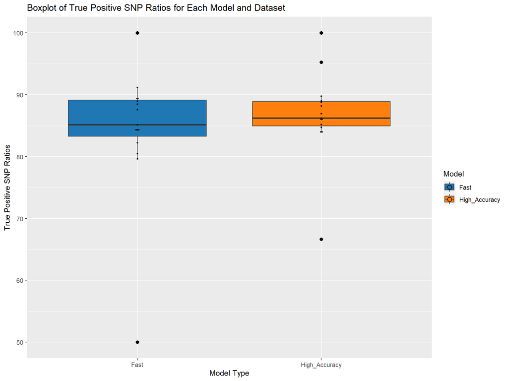

```r
ggplot(filtered_snps , aes(x = Model , y = TP_Ratios , fill = Model)) + geom_boxplot(outlier.color = "black" , outlier.shape = 16 , outlier.size = 2) + scale_fill_d3() + geom_dotplot(binaxis='y', stackdir='center',position=position_dodge(1) , binwidth = 0.2) + ggtitle("Boxplot of True Positive SNP Ratios for Each Model and Dataset") + xlab("Model Type") + ylab("True Positive SNP Ratios")
```

The True Positive differences are also tested using Paired T - Test to define the significance of differences.

First, the differences are with **Shapiro Wilk Test** to test normality.

```r
shapiro.test(filtered_snps$TP_Ratios[filtered_snps$Model == "Fast"] - filtered_snps$TP_Ratios[filtered_snps$Model == "High_Accuracy"])
```

```
##
##  Shapiro-Wilk normality test
##
## data:  filtered_snps$TP_Ratios[filtered_snps$Model == "Fast"] - filtered_snps$TP_Ratios[filtered_snps$Model == "High_Accuracy"]
## W = 0.92364, p-value = 0.2188
```

The TP Ratio differences are normally distributed with p-value = 0.22

```r
tp_ratios_test <- t.test(filtered_snps$TP_Ratios[filtered_snps$Model == "Fast"] , filtered_snps$TP_Ratios[filtered_snps$Model == "High_Accuracy"] ,paired = TRUE)

print(paste("Obtained P-Value is: " , round(tp_ratios_test$p.value,digits = 3)))
```

```
## [1] "Obtained P-Value is:  0.176"
```

Statistical Testing indicated that True Positive SNP Ratios are not statistically different between High Accuracy and Fast models.

## Comparison of Insertions and Deletions

Barplot of Number of Variants of Indels

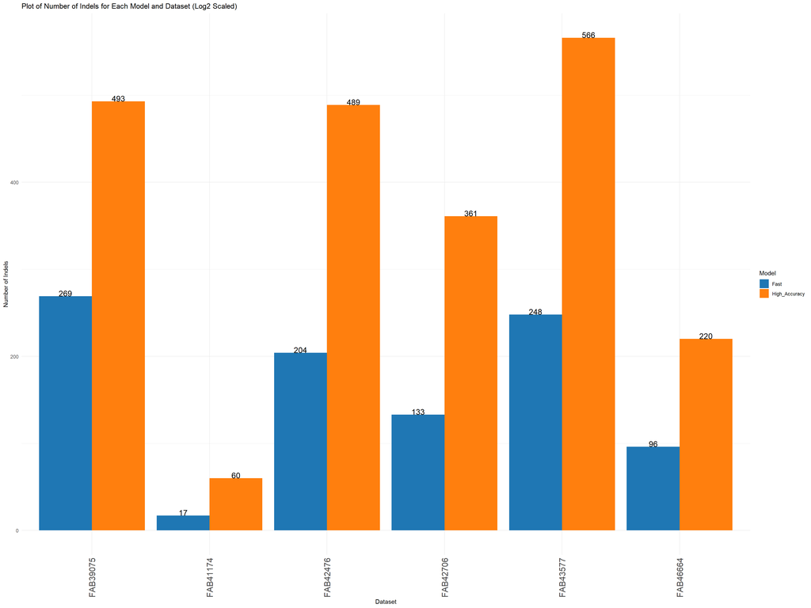

```r
ggplot(filtered_indels , aes(x = Dataset , Number_of_Variants , fill = Model , label = Number_of_Variants)) + geom_bar(stat = 'identity' , position = position_dodge()) + theme_minimal() + scale_fill_d3() + geom_text(aes(label = Number_of_Variants) , size = 5 , vjust = 0 , position = position_dodge(width = 0.9)) + theme(axis.text.x = element_text(angle = 90, size = 15, vjust = 0.5, hjust=1)) + ggtitle("Plot of Number of Indels for Each Model and Dataset (Log2 Scaled)") + xlab("Dataset") + ylab("Number of Indels")
```

Boxplot of Number of Variants of Indels

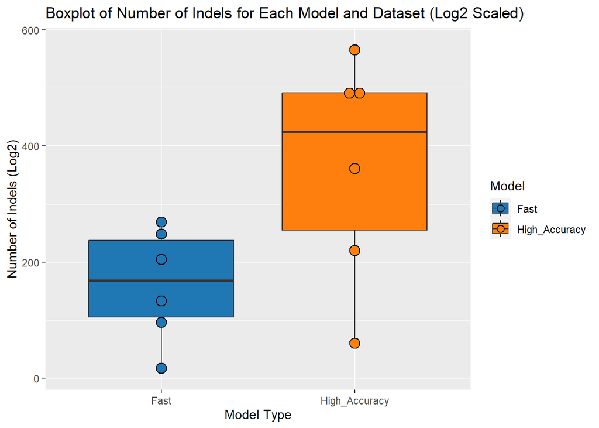

```r
ggplot(filtered_indels , aes(x = Model , y = Number_of_Variants , fill = Model)) + geom_boxplot(outlier.color = "black" , outlier.shape = 16) + scale_fill_d3() + geom_dotplot(binaxis='y', stackdir='center',position=position_dodge(1)) + ggtitle("Boxplot of Number of Indels for Each Model and Dataset (Log2 Scaled)") + xlab("Model Type") + ylab("Number of Indels (Log2)")
```

### Statistical Testing on Number of Variants

Fold Change Based Analysis

```r
number_of_indel_fcs <- filtered_indels$Number_of_Variants[filtered_indels$Model == "Fast"] / filtered_indels$Number_of_Variants[filtered_indels$Model == "High_Accuracy"]

tp_ratios_indel_fcs <- filtered_indels$TP_Ratios[filtered_indels$Model == "Fast"] / filtered_indels$TP_Ratios[filtered_indels$Model == "High_Accuracy"]

print(paste("Mean FoldChange of Number of Indels is: " , round(mean(number_of_indel_fcs) , digits = 3)))
```

```
## [1] "Mean FoldChange of Number of Indels is:  0.415"
```

```r
print(paste("Mean FoldChange of True Positive Indel Ratios is: " , round(mean(tp_ratios_indel_fcs) , digits = 3)))
```

```
## [1] "Mean FoldChange of True Positive Indel Ratios is:  0.925"
```

Average Fold Change of Indels between Fast and High Accuracy Models in the context of *Number of Variants* is 0.415 while in the context of *True Positive Ratios* is 0.925.

There is a remarkable difference between High Accuracy and Fast models in the context of **Number of Variants**.

The difference is also tested using Paired T - Test to define the significance of differences.

First, the differences are with **Shapiro Wilk Test** to test normality.

```r
shapiro.test(log2(filtered_indels$Number_of_Variants[filtered_indels$Model == "Fast"]) - log2(filtered_indels$Number_of_Variants[filtered_indels$Model == "High_Accuracy"]))
```

```
##
##  Shapiro-Wilk normality test
##
## data:  log2(filtered_indels$Number_of_Variants[filtered_indels$Model == "Fast"]) - log2(filtered_indels$Number_of_Variants[filtered_indels$Model == "High_Accuracy"])
## W = 0.94424, p-value = 0.6935
```

The differences distribute normally with p-value = 0.69

```r
number_of_variants_test_indels <- t.test(log2(filtered_indels$Number_of_Variants[filtered_indels$Model == "Fast"]) , log2(filtered_indels$Number_of_Variants[filtered_indels$Model == "High_Accuracy"]) ,paired = TRUE)

print(paste("Obtained P-Value is: " , round(number_of_variants_test_indels$p.value,digits = 3)))
```

```
## [1] "Obtained P-Value is:  0"
```

The Number of Variants are significantly different with p-value = 0.

### Statistical Testing on True Positive Ratios

Barplot of True Positive Rates of Indel Calls

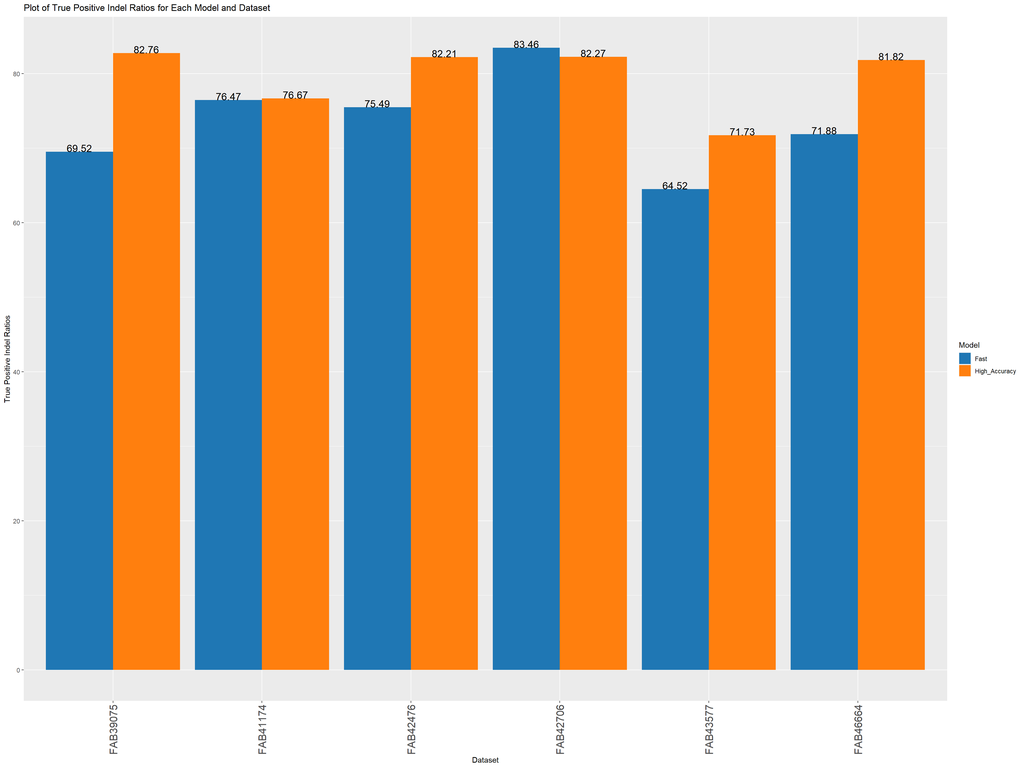

```r
ggplot(filtered_indels , aes(x = Dataset , y=TP_Ratios , fill = Model , label = round(TP_Ratios , digits = 2))) + geom_bar(stat = 'identity' , position = position_dodge())+ scale_fill_d3() + geom_text(aes(label = round(TP_Ratios , digits = 2)) , size = 5 , vjust = 0 , position = position_dodge(width = 0.9)) + theme(axis.text.x = element_text(angle = 90, size = 15, vjust = 0.5, hjust=1)) + ggtitle("Plot of True Positive Indel Ratios for Each Model and Dataset") + xlab("Dataset") + ylab("True Positive Indel Ratios")
```

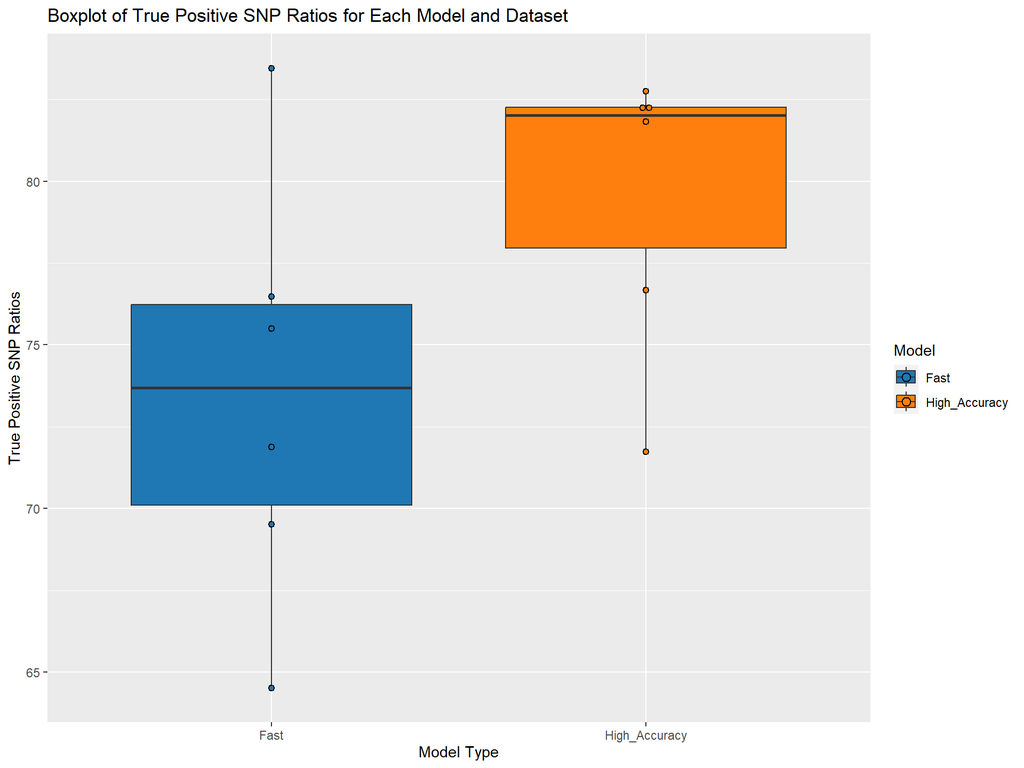

```r
ggplot(filtered_indels , aes(x = Model , y = TP_Ratios , fill = Model)) + geom_boxplot(outlier.color = "black" , outlier.shape = 16 , outlier.size = 2) + scale_fill_d3() + geom_dotplot(binaxis='y', stackdir='center',position=position_dodge(1) , binwidth = 0.2) + ggtitle("Boxplot of True Positive SNP Ratios for Each Model and Dataset") + xlab("Model Type") + ylab("True Positive SNP Ratios")
```

The True Positive differences are also tested using Paired T - Test to define the significance of differences.

First, the differences are with **Shapiro Wilk Test** to test normality.

```r
shapiro.test(filtered_indels$TP_Ratios[filtered_indels$Model == "Fast"] - filtered_indels$TP_Ratios[filtered_indels$Model == "High_Accuracy"])
```

```
##
##  Shapiro-Wilk normality test
##
## data:  filtered_indels$TP_Ratios[filtered_indels$Model == "Fast"] - filtered_indels$TP_Ratios[filtered_indels$Model == "High_Accuracy"]
## W = 0.93599, p-value = 0.6271
```

The TP Ratio differences are normally distributed with p-value = 0.63

```r
tp_ratios_test <- t.test(filtered_indels$TP_Ratios[filtered_indels$Model == "Fast"] , filtered_indels$TP_Ratios[filtered_indels$Model == "High_Accuracy"] ,paired = TRUE)

print(paste("Obtained P-Value is: " , round(tp_ratios_test$p.value,digits = 3)))
```

```
## [1] "Obtained P-Value is:  0.046"
```

Statistical Testing indicated that True Positive Indel Ratios are statistically different between High Accuracy and Fast models.

## Comparison of TP Ratio of Common Variants between Fast and High Accuracy Models

```r
common_comparison <- function(fast_input , hac_input , dataname) {
  fast_vcf <- read.table(fast_input , sep = "\t" , header = F)
  fast_vcf <- fast_vcf[fast_vcf$V7 == "PASS",]
  fast_vcf <- fast_vcf[as.numeric(fast_vcf$V6) > 12,]
  hac_vcf <- read.table(hac_input , sep = "\t" , header = F)
  hac_vcf <- hac_vcf[hac_vcf$V7 == "PASS",]
  hac_vcf <- hac_vcf[as.numeric(hac_vcf$V6) > 12,]
  fast_vcf$ID <- paste(fast_vcf$V1,fast_vcf$V2,fast_vcf$V4,fast_vcf$V5,sep = "_")
  hac_vcf$ID <- paste(hac_vcf$V1,hac_vcf$V2,hac_vcf$V4,hac_vcf$V5,sep = "_")
  common_variants <- intersect(fast_vcf$ID , hac_vcf$ID)
  number_of_common_variants <- length(common_variants)
  common_variants_tp <- sum(common_variants %in% truth_ids) / length(common_variants %in% truth_ids) * 100
  only_in_fast <- setdiff(fast_vcf$ID , hac_vcf$ID)
  only_in_hac <- setdiff(hac_vcf$ID , fast_vcf$ID)
  only_in_fast_tp <- sum(only_in_fast %in% truth_ids) / length(only_in_fast) * 100
  only_in_hac_tp <- sum(only_in_hac %in% truth_ids) / length(only_in_hac) * 100
  common_variants_results <- data.frame(Number_of_Common_Variants = number_of_common_variants,
                                   Common_Variants_TP = common_variants_tp,
                                   Only_In_Fast = length(only_in_fast),
                                   Only_In_High_Accuray = length(only_in_hac),
                                   Only_In_Fast_TP = only_in_fast_tp,
                                   Only_In_High_Accuracy_TP = only_in_hac_tp)
  rownames(common_variants_results) <- dataname
  common_variants_results
}
```

```r
for (i in 1:length(fast_vcfs_snps)) {
  assign(paste(sample_names[i],"_common_snps",sep = "") ,
       common_comparison(fast_vcfs_snps[i],hac_vcfs_snps[i],sample_names[i]))
}
```

```r
for (i in 1:length(fast_vcfs_indels)) {
  assign(paste(sample_names[i],"_common_indels",sep = "") ,
       common_comparison(fast_vcfs_indels[i],hac_vcfs_indels[i],sample_names[i]))
}
```

```r
common_snps <- as.data.frame(rbindlist(mget(ls(pattern = "_common_snps"))))

common_indels <- as.data.frame(rbindlist(mget(ls(pattern = "_common_indels"))))
```

```r
common_snps$Dataset <- as.character(rep(sample_names))
common_indels$Dataset <- as.character(rep(sample_names))
```

```r
common_snps <- as.data.frame(common_snps)
common_indels <- as.data.frame(common_indels[-c(1,3,5,6,7,8,11,13,14),])
```

```r
kable(common_snps , caption = "Variant Calling Results (SNPs)")
```

Variant Calling Results (SNPs)

| Number_of_Common_Variants | Common_Variants_TP | Only_In_Fast | Only_In_High_Accuray | Only_In_Fast_TP | Only_In_High_Accuracy_TP | Dataset |
| --- | --- | --- | --- | --- | --- | --- |
| 150 | 93.33333 | 104 | 383 | 82.69231 | 86.16188 | FAB39043 |
| 23725 | 92.29083 | 11467 | 43705 | 80.64882 | 88.41551 | FAB39075 |
| 4 | 100.00000 | 2 | 17 | 100.00000 | 94.11765 | FAB39088 |
| 3343 | 89.41071 | 1646 | 6470 | 74.17983 | 83.01391 | FAB41174 |
| 3 | 66.66667 | 3 | 15 | 33.33333 | 66.66667 | FAB42260 |
| 14 | 100.00000 | 5 | 20 | 60.00000 | 100.00000 | FAB42316 |
| 155 | 90.96774 | 79 | 381 | 81.01266 | 85.30184 | FAB42395 |
| 38 | 89.47368 | 16 | 78 | 56.25000 | 88.46154 | FAB42473 |
| 23837 | 89.77640 | 11731 | 48159 | 73.45495 | 84.47227 | FAB42476 |
| 18702 | 90.15079 | 9308 | 40401 | 72.58272 | 84.27514 | FAB42706 |
| 37 | 94.59459 | 31 | 82 | 87.09677 | 79.26829 | FAB42810 |
| 25535 | 90.75387 | 14138 | 51038 | 75.03890 | 83.55931 | FAB43577 |
| 41 | 92.68293 | 43 | 103 | 86.04651 | 81.55340 | FAB44989 |
| 26 | 92.30769 | 15 | 74 | 60.00000 | 87.83784 | FAB45332 |
| 13816 | 88.60741 | 7805 | 30978 | 70.94170 | 81.90329 | FAB46664 |

```r
rownames(common_indels) <- NULL
kable(common_indels , caption = "Variant Calling Results (Indels)")
```

Variant Calling Results (Indels)

| Number_of_Common_Variants | Common_Variants_TP | Only_In_Fast | Only_In_High_Accuray | Only_In_Fast_TP | Only_In_High_Accuracy_TP | Dataset |
| --- | --- | --- | --- | --- | --- | --- |
| 107 | 89.71963 | 162 | 386 | 56.17284 | 80.82902 | FAB39075 |
| 14 | 78.57143 | 3 | 46 | 66.66667 | 76.08696 | FAB41174 |
| 93 | 83.87097 | 111 | 396 | 68.46847 | 81.81818 | FAB42476 |
| 57 | 96.49123 | 76 | 304 | 73.68421 | 79.60526 | FAB42706 |
| 98 | 74.48980 | 150 | 468 | 58.00000 | 71.15385 | FAB43577 |
| 40 | 85.00000 | 56 | 180 | 62.50000 | 81.11111 | FAB46664 |

```r
standalone_variants <- as.data.frame(rbind(cbind(common_snps$Only_In_Fast_TP , common_snps$Only_In_High_Accuracy_TP) , cbind(common_indels$Only_In_Fast_TP , common_indels$Only_In_High_Accuracy_TP)))

common_variants_test <- t.test(standalone_variants$V1 , standalone_variants$V2
                               ,paired = TRUE)

print(paste("Obtained P-Value is: " , round(tp_ratios_test$p.value,digits = 3)))
```

```
## [1] "Obtained P-Value is:  0.046"
```

## Comparison of Single Nucleotide Polymorphmisms (SNPs)

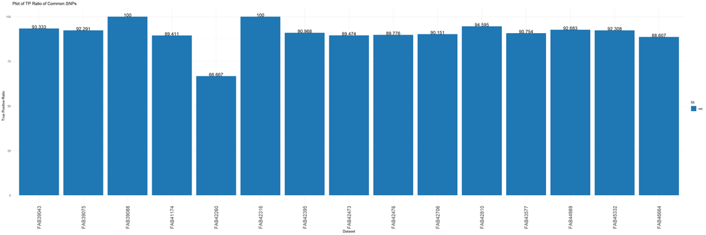

```r
ggplot(common_snps , aes(x = Dataset , y = Common_Variants_TP , fill = "red" , label = Common_Variants_TP)) + geom_bar(stat = 'identity' , position = position_dodge()) + theme_minimal() + scale_fill_d3() + geom_text(aes(label = round(Common_Variants_TP,digits = 3)) , size = 5 , vjust = 0 , position = position_dodge(width = 0.9)) + theme(axis.text.x = element_text(angle = 90, size = 15, vjust = 0.5, hjust=1)) + ggtitle("Plot of TP Ratio of Common SNPs") + xlab("Dataset") + ylab("True Positive Ratio")
```

### Comparison of Indels

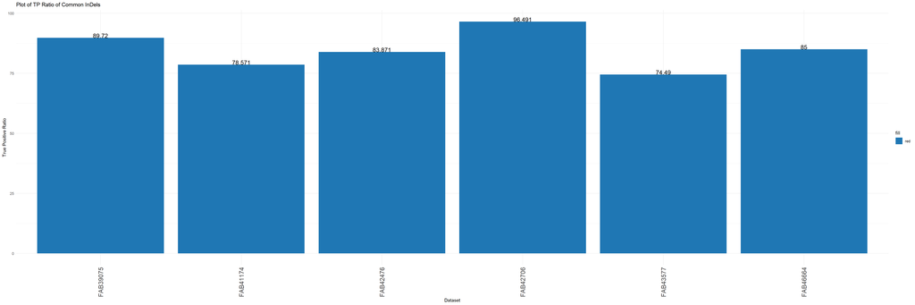

```r
ggplot(common_indels , aes(x = Dataset , y = Common_Variants_TP , fill = "red" , label = Common_Variants_TP)) + geom_bar(stat = 'identity' , position = position_dodge()) + theme_minimal() + scale_fill_d3() + geom_text(aes(label = round(Common_Variants_TP,digits = 3)) , size = 5 , vjust = 0 , position = position_dodge(width = 0.9)) + theme(axis.text.x = element_text(angle = 90, size = 15, vjust = 0.5, hjust=1)) + ggtitle("Plot of TP Ratio of Common InDels") + xlab("Dataset") + ylab("True Positive Ratio")
```

## Comparison of Qualities of Common Variants Between Models

```r
fast_snps_tsvs <- list.files("tsvs/snps/fast" , full.names = T)

hac_snps_tsvs <- list.files("tsvs/snps/hac" , full.names = T)

fast_indels_tsvs <- list.files("tsvs/indels/fast" , full.names = T)

hac_indels_tsvs <- list.files("tsvs/indels/hac" , full.names = T)
```

```r
quality_comparison <- function(fast_input , hac_input , dataname) {
  fast_tsv <- read.table(fast_input , sep = "\t" , header = T)
  hac_tsv <- read.table(hac_input , sep = "\t" , header = T)
  fast_tsv$IDs <- paste(fast_tsv$CHROM,fast_tsv$POS,fast_tsv$REF,fast_tsv$ALT , sep = "_")
  hac_tsv$IDs <- paste(hac_tsv$CHROM,hac_tsv$POS,hac_tsv$REF,hac_tsv$ALT , sep = "_")
  inters <- intersect(fast_tsv$IDs , hac_tsv$IDs)
  fast_tsv <- fast_tsv[fast_tsv$IDs %in% inters,]
  hac_tsv <- fast_tsv[hac_tsv$IDs %in% inters,]
  a <- cbind(fast_tsv$IDs , fast_tsv$QUAL, rep("fast" , nrow(fast_tsv)))
  b <- cbind(hac_tsv$IDs , hac_tsv$QUAL  , rep("hac" , nrow(hac_tsv)))
  data_table <- as.data.frame(rbind(a , b))
  colnames(data_table) <- c("Variant_ID" , "QUAL", "Model")
  data_table$QUAL <- as.numeric(data_table$QUAL)
  ggplot(data_table, aes(x=QUAL, colour=Model , fill = Model))+ geom_density(alpha=0.5) + ggtitle(dataname)
}
```

```r
sample_names <- list()

for (i in 1:length(fast_snps_tsvs)) {
  sample_names[i] <- substr(str_split(fast_snps_tsvs[i] , pattern = "/")[[1]][4],1,8)
}
```

```r
for (i in 1:length(fast_snps_tsvs)) {
      quality_comparison(fast_snps_tsvs[i],hac_snps_tsvs[i],sample_names[i])
}
```

```r
for (i in 1:length(fast_indels_tsvs)) {
      quality_comparison(fast_indels_tsvs[i],hac_indels_tsvs[i],sample_names[i])
}
```

### Statistical Testing on Qualities

```r
qualities_t_test <- function(fast_input , hac_input) {
  fast_tsv <- read.table(fast_input , sep = "\t" , header = T)
  hac_tsv <- read.table(hac_input , sep = "\t" , header = T)
  fast_tsv$IDs <- paste(fast_tsv$CHROM,fast_tsv$POS,fast_tsv$REF,fast_tsv$ALT , sep = "_")
  hac_tsv$IDs <- paste(hac_tsv$CHROM,hac_tsv$POS,hac_tsv$REF,hac_tsv$ALT , sep = "_")
  inters <- intersect(fast_tsv$IDs , hac_tsv$IDs)
  fast_tsv <- fast_tsv[fast_tsv$IDs %in% inters,]
  hac_tsv <- fast_tsv[hac_tsv$IDs %in% inters,]
  a <- as.numeric(fast_tsv$QUAL)
  b <- as.numeric(hac_tsv$QUAL)
  a <- log2(a)
  b <- log2(b)
  tp_qual_test <- t.test(a , b , paired = TRUE)
  p_value_qual <- round(tp_qual_test$p.value,digits = 3)
  p_value_qual
}
```

```r
p_values_qual_snps <- c()

for (i in 1:length(fast_snps_tsvs)) {
      p_values_qual_snps[i] <- qualities_t_test(fast_snps_tsvs[i],hac_snps_tsvs[i])
}

names(p_values_qual_snps) <- sample_names

p_values_qual_indels <- c()

for (i in 1:length(fast_indels_tsvs)) {
      try(p_values_qual_indels[i] <- qualities_t_test(fast_indels_tsvs[i],hac_indels_tsvs[i]),
          silent = TRUE)
}

names(p_values_qual_indels)  <- sample_names
```

```r
print(p_values_qual_snps)
```

```
## FAB39043 FAB39075 FAB39088 FAB41174 FAB42260 FAB42316 FAB42395 FAB42473 FAB42476 FAB42706 FAB42810
##    0.845    0.962    0.474    0.950    0.752    0.748    0.720    0.559    0.999    0.169    0.662
## FAB43577 FAB44989 FAB45332 FAB46664
##    0.215    0.818    0.270    0.599
```

```r
print(p_values_qual_indels)
```

```
## FAB39043 FAB39075 FAB39088 FAB41174 FAB42260 FAB42316 FAB42395 FAB42473 FAB42476 FAB42706 FAB42810
##    0.389    0.555       NA    0.065       NA       NA    0.232       NA    0.288    0.832    0.935
## FAB43577 FAB44989 FAB45332 FAB46664
##    0.300       NA       NA    0.512
```

## Comparison of False Negative SNPs and Indels

```r
fast_vcfs_snps <- list.files("clair3_vars/snps/fast" , full.names = T)
hac_vcfs_snps <- list.files("clair3_vars/snps/hac" , full.names = T)

fast_vcfs_indels <- list.files("clair3_vars/indels/fast" , full.names = T)
hac_vcfs_indels <- list.files("clair3_vars/indels/hac" , full.names = T)


truth_vcf_snps <- list.files("false_negative/snps"
                             , full.names = T)

truth_vcf_indels <- list.files("false_negative/indels"
                             , full.names = T)


fn_comparison <- function(fast_input , hac_input , dataname , truth_vcf) {
  fast_vcf <- read.table(fast_input , sep = "\t" , header = F)
  fast_vcf <- fast_vcf[fast_vcf$V7 == "PASS",]
  fast_vcf <- fast_vcf[as.numeric(fast_vcf$V6) > 12,]
  hac_vcf <- read.table(hac_input , sep = "\t" , header = F)
  hac_vcf <- hac_vcf[hac_vcf$V7 == "PASS",]
  hac_vcf <- hac_vcf[as.numeric(hac_vcf$V6) > 12,]
  fast_vcf$ID <- paste(fast_vcf$V1,fast_vcf$V2,fast_vcf$V4,fast_vcf$V5,sep = "_")
  hac_vcf$ID <- paste(hac_vcf$V1,hac_vcf$V2,hac_vcf$V4,hac_vcf$V5,sep = "_")
  truth_file <- read.table(truth_vcf , sep = "\t")
  truth_ids <- paste(truth_file$V1,truth_file$V2,truth_file$V4,truth_file$V5,sep = "_")
  fast_fn <- sum(!(truth_ids %in% fast_vcf$ID))
  hac_fn <- sum(!(truth_ids %in% hac_vcf$ID))
  fn <- data.frame(Number_of_Variants_In_Truth = nrow(truth_file),
                   Fast_False_Negative = fast_fn, High_Accuracy_False_Negative = hac_fn)
  rownames(fn) <- dataname
  fn
}

sample_names <- list()

for (i in 1:length(fast_vcfs_snps)) {
  sample_names[i] <- substr(str_split(fast_vcfs_snps[i] , pattern = "/")[[1]][4],1,8)
}


for (i in 1:length(fast_vcfs_snps)) {
  assign(paste(sample_names[i],"_fn_snps",sep = "") ,
         fn_comparison(fast_vcfs_snps[i],hac_vcfs_snps[i],sample_names[i],truth_vcf_snps[i]))
}

results <- ls(pattern = "_fn_snps")

false_negative_snps <- rbind(get(results[1]) , get(results[2]))

for (i in 3:15) {
  false_negative_snps <- rbind(false_negative_snps , get(results[i]))
}


for (i in 1:length(fast_vcfs_snps)) {
  assign(paste(sample_names[i],"_fn_indels",sep = "") ,
         fn_comparison(fast_vcfs_indels[i],hac_vcfs_indels[i],sample_names[i],truth_vcf_indels[i]))
}

results <- ls(pattern = "_fn_indels")

false_negative_indels <- rbind(get(results[1]) , get(results[2]))

for (i in 3:15) {
  false_negative_indels <- rbind(false_negative_indels , get(results[i]))
}

false_negative_indels <- false_negative_indels[!(false_negative_indels$Number_of_Variants_In_Truth == false_negative_indels$Fast_False_Negative),]

p_val_fn_snps <- t.test(false_negative_snps$Fast_False_Negative ,
                        false_negative_snps$High_Accuracy_False_Negative, paired = TRUE)

p_val_fn_indels <- t.test(false_negative_indels$Fast_False_Negative ,
                        false_negative_indels$High_Accuracy_False_Negative, paired = TRUE)
```

```r
print(p_val_fn_snps)
```

```
##
##  Paired t-test
##
## data:  false_negative_snps$Fast_False_Negative and false_negative_snps$High_Accuracy_False_Negative
## t = 2.7245, df = 14, p-value = 0.01645
## alternative hypothesis: true mean difference is not equal to 0
## 95 percent confidence interval:
##   2064.278 17337.722
## sample estimates:
## mean difference
##            9701
```

```r
print(p_val_fn_indels)
```

```
##
##  Paired t-test
##
## data:  false_negative_indels$Fast_False_Negative and false_negative_indels$High_Accuracy_False_Negative
## t = 4.9686, df = 5, p-value = 0.004217
## alternative hypothesis: true mean difference is not equal to 0
## 95 percent confidence interval:
##   84.05829 264.27504
## sample estimates:
## mean difference
##        174.1667
```

# Conclusion

Due to small sample size, the statistical test results may not be generalized but when the results investigated in detail, it can be seen the *High Accuracy* and *Fast* models are different in the context of *Pass/Fail Ratio* and *Number of Variants*. However, total read counts of FASTQ files and *True Positive Rates* are not significantly different for Single Nucleotide Polymorphisms while *True Positive Rates* for Insertions/Deletions are significantly different.